# Homework3: Connect Your Brain

Alessandro Quattrociocchi - Juan Mata Narajo

2/16/2021

## Homework Setup and Interpretation

The main goal of this homework is to explore and infer association measures from two type of subjects:

- Autism Spectrum Disorder (ASD)
- Typically Developed (TD)

The connection between ROI’s of a brain can be seen as a graph $G = (V, \epsilon)$, where $V$ represents the nodes of this graph (in our case ROI’s) and $\epsilon$ the edges that connect these nodes together.

We will initially estimate $G = (V, \epsilon)$ through $\hat{G}(t) = (V, \epsilon(t))$ for both types of subjects. This implies that we will have to infer this unknown graph using a set of random samples (asd_sel and td_sel) which we will denote as $D_n$, and more preciselly, what we will need to infer in order to construct such a graph is an association measure between the realizations of this “true” and unknown graph. The association measure we will focus on throughout the whole homework is the Pearson Correlation value. We choose to use this association measure because it allows us to find out whether two random variables are linearly correlated and more importantly, there is a transformation of this association measure which is assymptotically normal (with known mean and variance), allowing us to produce more accurate estimates. In particular, given the following plug-in estimate of the Pearson Correlation measure, the transformation (Fisher Z-transform) has the following shape:

$$\begin{align*}
\hat{\rho(X, Y)} = \frac{\frac{1}{n}\sum^{n}_{i=1}(X_i - \overline{X}_n)(Y_i - \overline{Y}_n)}{S_X\cdot S_Y}
\end{align*}$$

$$\begin{align*}
Z_{X, Y} = \frac{1}{2}log\bigg(\frac{1+\hat{\rho}_{X, Y}^{(i)}}{1-\hat{\rho}_{X, Y}^{(i)}}\bigg)
\end{align*}$$

In our case X and Y will represent two different ROI’s, which we will denote as $j$ and $k$ from now onward.

Now that we have choosen what association measure we want to use we have to decide how to set or not set an edge between two nodes. Given that we are testing different random samples we can see it as a Hypothesis testing approach:

$$\begin{align*}
H_o: |\rho_{j, k}| < t
\end{align*}$$

against:

$$\begin{align*}
H_1: |\rho_{j, k}| \geq t
\end{align*}$$

Or in terms of CI we are basically saying that we should set an edge between two vertices if the following holds:

$$\begin{align*}
[-t, +t] \cap C^{j,k}_n(\alpha) = \emptyset
\end{align*}$$

The previous equation is therefore our final goal, which needs to be evaluated individually over all of the different ROI’s. However, before jumping into the final calculations, we need to realize that 3 main ingredients are needed:

- *t*: What t-threshold should we use for this purpose? We will choose the 80th percentile among all the correlation values.
- *$\alpha$*: We will use a 95% confidence level, but since we are performing multiple tests, to avoid multiplicity we will use the Bonferroni correction: $\alpha_{B} = \frac{\alpha}{\binom{D}{2}}$
- *Confidence Interval*: We need to construct an appropriate confidence interval around our estimated $\rho_{j, k}$ values. For this purpose we will use the Fisher Z-transformation presented previously.

#### Data Processing and Data Pooling

For each of these two types of patients we have data for 12 different (and independent) subjects. For each patient we have information regarding 116 different ROI’s as a time series. For simplicity will also assume that the data of this time series is also independent and identically distributed.

Since we have information about 12 different subjects and our final goal is to get a feeling about the overall connectomics we will first pool all the data of these subjects together. We have considered two approaches, finally deciding for the second:

- We are assuming that the subjects are similar between each other (the subjects of the same group of course) since we are manually eliminating possible confounding factors such as sex and age. This implies data is independent and identically distributed between each other.
- Construct the correlation matrix of each subject individually and then group then together by averaging. This approach seemed to be the better choice since it not only allows us to pool data together, but it also allows us to reduce the variance of our final estimate.

In order to average the correlation matrices together we have also decided to first transform them into their Fisher Z random variable:

$$\begin{align*}
\overline{Z}_{j, k} = \frac{1}{12}\sum_{i=1}^{12}Z_{j, k}^{(i)}
\end{align*}$$

```r
cor.asd = lapply(asd_sel, cor)
cor.td = lapply(td_sel, cor)
```

```r
z.fisher.asd = lapply(cor.asd, function(x) .5*log((1+x)/(1-x)))
z.fisher.td = lapply(cor.td, function(x) .5*log((1+x)/(1-x)))
```

```r
z.fisher.asd.hat = apply(simplify2array(z.fisher.asd), 1:2, mean)
z.fisher.td.hat = apply(simplify2array(z.fisher.td), 1:2, mean)
```

#### Graph Construction (CI’s and t-threshold)

With all the previous ingredients we can start constructing an asymptotically normal confidence interval around each of the $\overline{Z}_{j, k}$ for a specific alpha value using the following equation:

$$\begin{align*}
C_{Z}^{(j, k)}(\alpha) = [\overline{Z}_{j, k} \pm z_{\alpha/2}\hat{se}(\overline{Z}_{j, k})]
\end{align*}$$

where:

$$\begin{align*}
\hat{se}(\overline{Z}_{j, k}) = \sqrt{Var(\overline{Z}_{j, k}))} = \sqrt{\frac{1}{m^2}m Var(Z_{j, k}^{(i)})} = \sqrt{\frac{1}{m\cdot(n-3)}}
\end{align*}$$

where $m$ is the number of subjects (12) and $n$ the sample size (145).

```r
ci.z.fisher.asd = array(NA, dim = c(116, 116, 2),
                        dimnames = list(rownames(z.fisher.asd.hat),
                                        rownames(z.fisher.asd.hat),
                                        c('Lower', 'Upper')))
ci.z.fisher.td = array(NA, dim = c(116, 116, 2),
                       dimnames = list(rownames(z.fisher.asd.hat),
                                       rownames(z.fisher.asd.hat),
                                       c('Lower', 'Upper')))

# Bonferroni Correction
alpha = .05/choose(116, 2)

for (i in rownames(z.fisher.asd.hat)) {
  for (j in rownames(z.fisher.asd.hat)) {
    ci.z.fisher.asd[i, j, 'Lower'] = z.fisher.asd.hat[i, j] - qnorm(1-alpha/2)*sqrt(1/(12*(145-3)))
    ci.z.fisher.asd[i, j, 'Upper'] = z.fisher.asd.hat[i, j] + qnorm(1-alpha/2)*sqrt(1/(12*(145-3)))
    ci.z.fisher.td[i, j, 'Lower'] = z.fisher.td.hat[i, j] - qnorm(1-alpha/2)*sqrt(1/(12*(145-3)))
    ci.z.fisher.td[i, j, 'Upper'] = z.fisher.td.hat[i, j] + qnorm(1-alpha/2)*sqrt(1/(12*(145-3)))
  }
}
```

Finally, we will convert the Z-transform confidence intervals back into correlation confidence intervals (go from Z-space to [-1, 1]-space) by applying the inverse Fisher Z-transform:

```r
ci.rho.asd = array(NA, dim = c(116, 116, 2),
                          dimnames = list(rownames(z.fisher.asd.hat),
                                          rownames(z.fisher.asd.hat),
                                          c('Lower', 'Upper')))
ci.rho.td = array(NA, dim = c(116, 116, 2),
                         dimnames = list(rownames(z.fisher.asd.hat),
                                         rownames(z.fisher.asd.hat),
                                         c('Lower', 'Upper')))

for (i in rownames(z.fisher.asd.hat)) {
  for (j in rownames(z.fisher.asd.hat)) {
    ci.rho.asd[i, j, 'Lower'] = tanh(ci.z.fisher.asd[i, j, 'Lower'])
    ci.rho.asd[i, j, 'Upper'] = tanh(ci.z.fisher.asd[i, j, 'Upper'])
    ci.rho.td[i, j, 'Lower'] = tanh(ci.z.fisher.td[i, j, 'Lower'])
    ci.rho.td[i, j, 'Upper'] = tanh(ci.z.fisher.td[i, j, 'Upper'])
  }
}
```

Before testing whether an edge should be generated or not we have to estimate the threshold as previously mentioned:

```r
rho.asd.hat = tanh(z.fisher.asd.hat)
rho.td.hat = tanh(z.fisher.td.hat)

t.vec = c(rho.asd.hat[upper.tri(rho.asd.hat, diag = FALSE)],
          rho.td.hat[upper.tri(rho.td.hat, diag = FALSE)])

t.threshold = quantile(t.vec, probs = .8)
t.CI = c(-1, 1)*t.threshold
t.CI
```

```
## [1] -0.1241823  0.1241823
```

We now look for edges in which t interval and CI interval don’t overlap (hypothesis test fails)

```r
edge_detector <- function(matrix, lower.bound, upper.bound){
  adj_matrix = array(NA, dim = c(116, 116),
                     dimnames = list(rownames(matrix),
                                     rownames(matrix)))
  corr.counter = 0
  for (i in rownames(matrix)) {
    for (j in rownames(matrix)) {
      if (i == j) {
        adj_matrix[i,j] = 0
      }
      else if (is.na(matrix[i, j,"Upper"]) || is.na(matrix[i, j,"Lower"])) {
        adj_matrix[i,j] = adj_matrix[j, i]
      }
      else if((matrix[i, j,"Upper"] <= lower.bound) || (matrix[i, j,"Lower"] >= upper.bound)) {
        adj_matrix[i,j] = 1
        corr.counter = corr.counter + 1
      }
      else{
        adj_matrix[i,j] = 0
      }
    }
  }
  cat("Number of edges: ", corr.counter/2)
  return(adj_matrix)
}


adj.matrix.asd <- edge_detector(matrix = ci.rho.asd, lower.bound = t.CI[1], upper.bound = t.CI[2] )
```

```
## Number of edges:  1073
```

```r
adj.matrix.td <- edge_detector(matrix = ci.rho.td, lower.bound = t.CI[1], upper.bound = t.CI[2] )
```

```
## Number of edges:  1175
```

#### Graphical Representation

With the adjacency matrix constructed previously we can represent our estimated connectome for both types of patients.

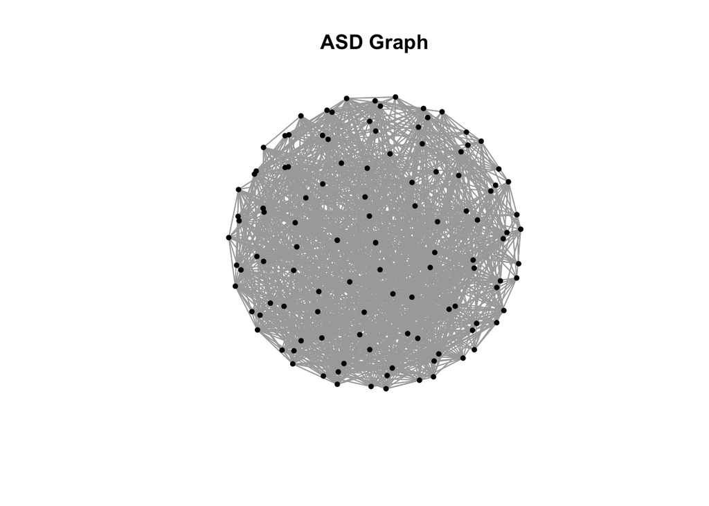

```r
graph.from.adjm <- function(adj.matrix, plot_name = 'ASD Graph'){
  g <- graph_from_adjacency_matrix(adj.matrix)
  l <- layout.sphere(g)
  plot(simplify(g, remove.loops = TRUE, remove.multiple = TRUE), layout = l,
       edge.arrow.size=0, vertex.color="black", vertex.size=3,
       vertex.frame.color="black", vertex.label.color="black",
       vertex.label.cex=0.8, edge.curved=0,
       vertex.label=NA, main = plot_name)
}

graph.from.adjm(adj.matrix.asd, plot_name = 'ASD Graph')
```

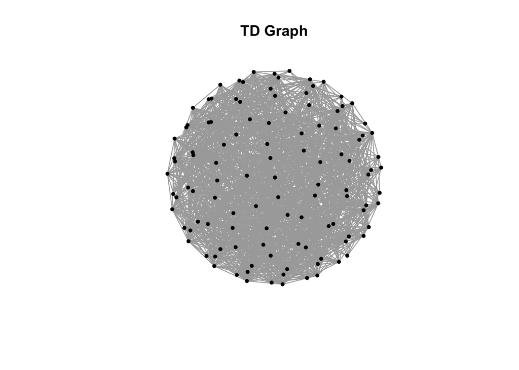

```r
graph.from.adjm(adj.matrix.td, plot_name = 'TD Graph')
```

Finally we will also compare the number of edges that would have been generated in case we would not have considered correcting for multiplicity:

| Number of edges in the graph | ASD | TD |
| --- | --- | --- |
| With Bonferroni Correction | 1073 | 1175 |
| Without Bonferroni Correction | 1893 | 1971 |

We can highlight the difference in behaviour when using the Bonferroni correction. For example, in the case of ASD, the difference between the edges obtained with and without Bonferroni adjustment is 820 edges, while for TD it is 796 edges. In general, we can remark the conservative approach lead to compensation with Bonferroni. The immediate result we can see is that with this correction, the graph decreases the number of edges, i.e. the number of discoveries. Additionally, from what has been observed we can say that in subjects with ASD we have fewer correlations (and therefore fewer edges in the graph) than in subjects with TD. This is a crucial point taken into consideration by many scientists in many articles because some of them tend to link hypoconnectivity as an endophenotype of autism. Others, however, have tried to demonstrate the opposite but in general, we know that several competing factors must be taken into account to draw more general conclusions. What we can say is that we tend to see this type of behaviour.

### Bonus Question

Another relevant point of research could be to find the ROI’s between which the correlation measures of two different subject types is different. These ROI’s would therefore be the ones which most likely should be further investigated to try and find cures or have a better understanding of ASD subjects.

For this purpose we will use a Bootstrap approach to construct the confidence interval around our estimate of interest:

$$\begin{align*}
|\Delta_{j, k}| = |\rho^{ASD}_{j, k} - \rho^{TD}_{j,k}| \geq t
\end{align*}$$

In this case we will also use the Fisher Z-transform instead of working with the Pearson correlation directly (this will allow us to build Normal Confidence Intervals):

$$\begin{align*}
\Delta^Z_{j, k} = Z^{ASD}_{j, k} - Z^{TD}_{j,k}
\end{align*}$$

Where we will use the fact that $Z_{j, k}^{ASD}$ and $Z_{j, k}^{TD}$ are both normally distributed, therefore $\Delta^Z_{j, k}$ will also be normally distributed.

Another difference to the previous pooling strategy is that we will no longer pool by averaging the correlation measures, instead we will now use the first strategy proposed:

- We are assuming that the subjects are similar between each other (the subjects of the same group of course) since we are manually eliminating possible confounding factors such as sex and age. This implies data is independent and identically distributed between each other.

The reason is that this will allow us to have a larger sample for our bootstrap to re-sample from. The code below does this aggregation, and computes the estimated $\hat{\Delta}^Z_{j, k}$.

```r
asd.complete = bind_rows(asd_sel)
td.complete = bind_rows(td_sel)

cor.asd.complete =  cor(asd.complete)
cor.td.complete =  cor(td.complete)

z.fisher.cor.asd.complete = atanh(cor.asd.complete)
z.fisher.cor.td.complete = atanh(cor.td.complete)

z.fisher.hat.diff = z.fisher.cor.asd.complete - z.fisher.cor.td.complete
```

We will now use the bootstrap in order to find a proper Normal Confidence interval around $\hat{\Delta}^Z_{j, k}$, and similarly to before, set an edge between our difference graph whenever the following holds:

$$\begin{align*}
[-t, +t] \cap C^{j,k, \Delta}_n(\alpha) = \emptyset
\end{align*}$$

In this case, we will compute the t-threshold over the Z-space and decide to set an edge or not in this Z-space. Similarly to before, we will also compute the t-threshold using the 80th percentile of the $\hat{\Delta}^Z_{j, k}$ values.

```r
t.vec = z.fisher.hat.diff[upper.tri(z.fisher.hat.diff, diag = FALSE)]

t.threshold.boot = quantile(t.vec, probs = .8)
t.CI.boot = c(-1, 1)*t.threshold.boot
t.CI.boot
```

```
## [1] -0.08703963  0.08703963
```

Finally we can start setting up the bootstrap (takes long to run, therefore we have set the markdown to not run this part and instead load the file “se.boot.vec” which has all relevent results):

```r
# Number of Bootstrap simulations
B = 1000

# Vector in which we will include the standard error of each bootstrap
se.boot.vec = array(NA, dim = c(116, 116),
                    dimnames = list(rownames(z.fisher.asd.hat),
                                    rownames(z.fisher.asd.hat)))

row. = 0
col. = 0
for (j in rownames(z.fisher.asd.hat)) {
  row. = row. + 1
  col. = 0
  for (k in rownames(z.fisher.asd.hat)) {
    col. = col. + 1
    if (row. < col.) {
      # We will create a new boot  vector every time for each of  the j, k, no
      # need to store all this info since we are only interested in the standard error
      temp.boot.vec = rep(NA, B)
      for (b in 1:B) {
        # Get sample index for ASD and TD (for both ROI's)
        idx_ASD_j = sample(1:nrow(asd.complete), replace = T)
        idx_ASD_k = sample(1:nrow(asd.complete), replace = T)
        idx_TD_j = sample(1:nrow(td.complete), replace = T)
        idx_TD_k = sample(1:nrow(td.complete), replace = T)

        # Get the samples from complete subject
        xx_ASD_j = asd.complete[j][idx_ASD_j,]
        xx_ASD_k = asd.complete[k][idx_ASD_k,]
        xx_TD_j = td.complete[j][idx_TD_j,]
        xx_TD_k = td.complete[k][idx_TD_k,]

        # Construct Pearson Correlation
        rho.ASD.boot = cor(xx_ASD_j, xx_ASD_k)
        rho.TD.boot = cor(xx_TD_j, xx_TD_k)

        # Transform Correlation using Z-transform
        z.fisher.ASD.boot = atanh(rho.ASD.boot)
        z.fisher.TD.boot = atanh(rho.TD.boot)

        # Construct the difference and store it in the matrix accordingly
        temp.boot.vec[b] = z.fisher.ASD.boot - z.fisher.TD.boot
      }
      se.boot.vec[j, k] = sd(temp.boot.vec)
    }
  }
}
```

Construct the Normal Confidence Intervals using the results from the bootstrap:

```r
# Bonferroni
alpha = .05/choose(116, 2)

# Construct Non-Parametric Confidence Interval (we will only look into the Normal Bootstrap CI)
CI.boot.vec = array(NA, dim = c(116, 116, 2),
                    dimnames = list(rownames(z.fisher.asd.hat),
                                    rownames(z.fisher.asd.hat),
                                    c('Lower', 'Upper')))

for (i in rownames(z.fisher.asd.hat)) {
  for (j in rownames(z.fisher.asd.hat)) {
    CI.boot.vec[i, j, 'Lower'] = z.fisher.hat.diff[i, j] - qnorm(1-alpha/2)*se.boot.vec[i, j]
    CI.boot.vec[i, j, 'Upper'] = z.fisher.hat.diff[i, j] + qnorm(1-alpha/2)*se.boot.vec[i, j]
  }
}
```

As in the previous case we can now generate the graph and plot it:

```r
adj.matrix.diff <- edge_detector(matrix = CI.boot.vec, lower.bound = t.CI.boot[1],
                                 upper.bound = t.CI.boot[2] )
```

```
## Number of edges:  90.5
```

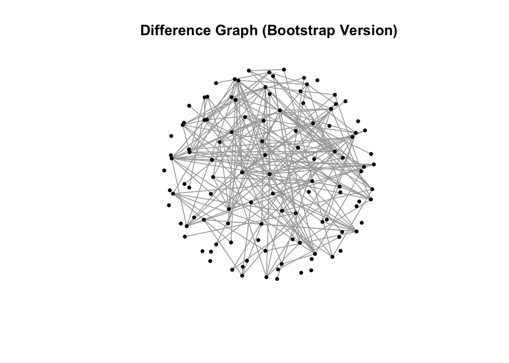

```r
graph.from.adjm(adj.matrix.diff, plot_name = 'Difference Graph (Bootstrap Version)')
```

In this last part, we studied the difference correlation graph between ASD and TD subjects. This method allows us to quickly visualize regions that have different correlation behaviours between ROI’s, represented through an edge. In particular, and as expected, there are several ROI’s which have different correlation measures between each other. This aspect is fundamental to identify the areas on which to carry out more studies and look for the causes of the disorder.